# Montserrat Forest Bird Monitoring - Annual Summary

Department of Environment / RSPB

The forests on Montserrat are home for two globally threatened forest bird species, the endemic Montserrat Oriole and the Forest Thrush. Since 1999 the Department of Environment and the RSPB have counted the forest birds in the Center Hills along 11 survey routes at least once per year at the beginning of the birds’ breeding season in April.

### Summary of raw observations in April and May 2024

Observed number of forest birds in the Centre Hills of Montserrat in April and May 2024 during three independent survey rounds.

| Species | Total N in round 1 | Total N in round 2 | Total N in round 3 |
| --- | --- | --- | --- |
| PEARLY-EYED THRASHER | 394 | 433 | 434 |
| SCALY-NAPED PIGEON | 307 | 354 | 325 |
| BANANAQUIT | 181 | 204 | 196 |
| SCALY-BREASTED THRASHER | 123 | 134 | 133 |
| FOREST THRUSH | 97 | 188 | 182 |
| BROWN TREMBLER | 63 | 66 | 66 |
| BRIDLED QUAIL-DOVE | 51 | 76 | 77 |
| ANTILLEAN CRESTED HUMMINGBIRD | 42 | 30 | 30 |
| MONTSERRAT ORIOLE | 40 | 60 | 50 |
| PURPLE-THROATED CARIB | 35 | 37 | 34 |
| CARIBBEAN ELAENIA | 0 | 0 | 2 |
| GREEN-THROATED CARIB | 0 | 0 | 0 |

### Estimate of forest bird trends on Montserrat since 2011

Since the survey design with three repeated counts at each point was introduced in 2011, we use binomial mixture models to estimate the abundance of birds around all survey points, and the long term trend across years. The three repeated visits allow us to estimate what proportion of birds were not seen during the surveys, so that the estimated number is less affected by temporal changes in weather or bird calling activity, and the estimated trend should not be affected by differences between observation conditions in different years.

There is no indication that the two globally threatened species (Montserrat Oriole and Forest Thrush) have decreased since 2011, in fact, the Montserrat Oriole appears to have slightly increased. However, Green-throated Caribs appear to have been affected by the hurricanes in 2017, and both Green-throated Caribs and Caribbean Elaenia have a long-term negative trend (Fig. 1, Table 2).

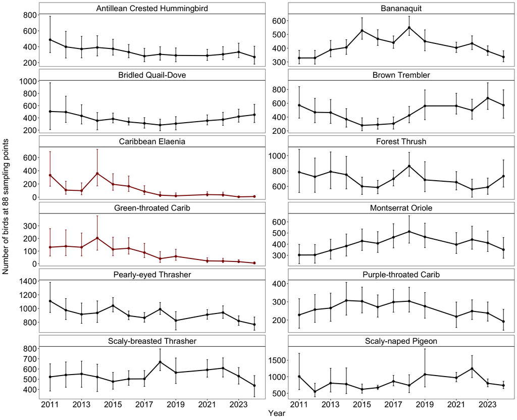

Estimated trend of 12 forest bird species surveyed between 2011 and 2024 in the Centre Hills of Montserrat. Note that ‘model fit’ is assessed via a Bayesian p-value, which indicates poor model fit at values close to 0 and close to 1.

| Species | Direction | Trend estimate | Model fit |
| --- | --- | --- | --- |
| Antillean Crested Hummingbird | stable | -0.13 (-0.29 - 0.03) | 0.00 |
| Bananaquit | stable | 0.02 (-0.06 - 0.1) | 0.00 |
| Bridled Quail-Dove | stable | -0.04 (-0.22 - 0.16) | 0.18 |
| Caribbean Elaenia | decrease | -1.08 (-1.63 - -0.51) | 0.93 |
| Forest Thrush | stable | -0.05 (-0.19 - 0.1) | 0.01 |
| Green-throated Carib | decrease | -0.98 (-1.35 - -0.6) | 0.59 |
| Montserrat Oriole | stable | 0.08 (-0.01 - 0.18) | 0.25 |
| Pearly-eyed Thrasher | stable | -0.07 (-0.15 - 0) | 0.00 |
| Purple-throated Carib | stable | -0.06 (-0.19 - 0.09) | 0.00 |
| Scaly-breasted Thrasher | stable | 0.01 (-0.1 - 0.13) | 0.00 |
| Scaly-naped Pigeon | stable | 0.08 (-0.11 - 0.25) | 0.16 |
| Brown Trembler | stable | 0.11 (-0.08 - 0.31) | 0.73 |